# case_IBM

### 3.6. Avaliação de Resultados

Primeiro avaliado os resultados no sample 'analise_preditiva.csv', e depois comparado a generalização com o dataset de produção.

#### 3.6.1. Dataset de Teste - analise-preditiva.xlsx (50 amostras)

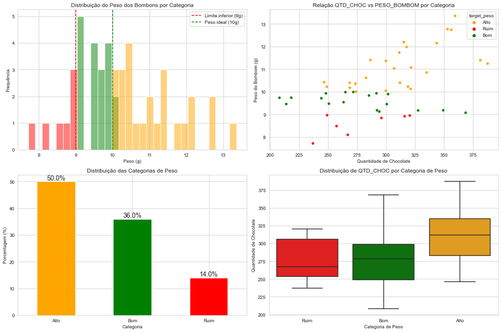

```python
# Classificação do peso
df_pred['target_peso'] = np.where(df_pred['PESO_BOMBOM'] > 10.0, "Alto",
                    np.where((df_pred['PESO_BOMBOM'] >= 9.0) & (df_pred['PESO_BOMBOM'] <= 10.0), "Bom",
                             "Ruim"))

# Categorias de conformidade
conforme = df_pred[(df_pred['PESO_BOMBOM'] >= 9.0) & (df_pred['PESO_BOMBOM'] <= 10.0)]
conforme_custo_alto = df_pred[(df_pred['PESO_BOMBOM'] > 10.0)]
nao_conforme = df_pred[(df_pred['PESO_BOMBOM'] < 9.0)]

plt.figure(figsize=(15, 10))

# Relação Target_Peso vs PESO_BOMBOM com categorias
plt.subplot(2, 2, 1)
sns.histplot(data=df_pred, x='PESO_BOMBOM', hue='target_peso', bins=30, palette={'Ruim': 'red', 'Bom': 'green', 'Alto': 'orange'})
plt.axvline(x=9.0, color='r', linestyle='--', label='Limite inferior (9g)')
plt.axvline(x=10.0, color='g', linestyle='--', label='Peso ideal (10g)')
plt.title('Distribuição do Peso dos Bombons por Categoria')
plt.xlabel('Peso (g)')
plt.ylabel('Frequência')
plt.legend()

# Relação QTD_CHOC vs PESO_BOMBOM com categorias
plt.subplot(2, 2, 2)
sns.scatterplot(x='QTD_CHOC', y='PESO_BOMBOM', hue='target_peso', data=df_pred, palette={'Ruim': 'red', 'Bom': 'green', 'Alto': 'orange'})
plt.title('Relação QTD_CHOC vs PESO_BOMBOM por Categoria')
plt.xlabel('Quantidade de Chocolate')
plt.ylabel('Peso do Bombom (g)')

# Proporção de cada categoria
plt.subplot(2, 2, 3)
categorias = df_pred['target_peso'].value_counts(normalize=True) * 100
categorias.plot(kind='bar', color=['orange', 'green', 'red'])
plt.title('Distribuição das Categorias de Peso')
plt.xlabel('Categoria')
plt.ylabel('Porcentagem (%)')
plt.bar_label(plt.gca().containers[0], fmt='%.1f%%', fontsize=14)
plt.xticks(rotation=0)

# Boxplot de QTD_CHOC por categoria
plt.subplot(2, 2, 4)
sns.boxplot(x='target_peso', y='QTD_CHOC', data=df_pred, order=['Ruim', 'Bom', 'Alto'], palette={'Ruim': 'red', 'Bom': 'green', 'Alto': 'orange'})
plt.title('Distribuição de QTD_CHOC por Categoria de Peso')
plt.xlabel('Categoria de Peso')
plt.ylabel('Quantidade de Chocolate')

plt.tight_layout()
plt.show()
```

```python
df_pred.groupby('target_peso').size().reset_index(name='counts')
```

|  | target_peso | counts |
| --- | --- | --- |
| 0 | Alto | 25 |
| 1 | Bom | 18 |
| 2 | Ruim | 7 |

```python
# Definir a função de custo
def calcular_custo(p):
    """
    Calcula o custo C(p) baseado no peso p do bombom.

    Parâmetros:
    p -- peso do bombom (float)

    Retorna:
    Valor do custo calculado
    """
    termo1 = 200 / (1 + np.exp(10 * (p - 9.5)))
    termo2 = 200 / (1 + np.exp(-0.8 * (p - 12)))
    return termo1 + termo2

df_pred['custo'] = calcular_custo(df_pred['PESO_BOMBOM'])

print("\nEstatísticas descritivas do custo:")
df_pred_custo = df_pred['custo'].describe().to_frame(name='custo')
df_pred_custo
```

```
Estatísticas descritivas do custo:
```

|  | custo |
| --- | --- |
| count | 50.000000 |
| mean | 103.426695 |
| std | 70.063722 |
| min | 34.723674 |
| 25% | 42.704662 |
| 50% | 75.689735 |
| 75% | 148.529828 |
| max | 215.266739 |

```python
# Cálculo da distribuição percentual do custo- Por Classe
agg_class = (
    df_pred[['target_peso', 'VAR_2','custo']].groupby(['target_peso', 'VAR_2'])
    .sum('custo')
    .unstack(fill_value=0)
    .round(0)
)

agg_percent = agg_class.div(agg_class.sum(axis=0))*100
agg_percent_tl = pd.concat([
    agg_class.add_suffix('_n'),
    agg_percent.round(1).add_suffix('_%')
], axis=1)

agg_percent_tl.loc['Total'] = agg_percent_tl.sum(axis=0)

agg_percent_tl
```

| VAR_2 target_peso | custo_n A_n | custo_n B_n | custo_n C_n | custo_% A_% | custo_% B_% | custo_% C_% |
| --- | --- | --- | --- | --- | --- | --- |
| Alto | 1069.0 | 367.0 | 305.0 | 93.7 | 11.1 | 41.9 |
| Bom | 72.0 | 1450.0 | 423.0 | 6.3 | 43.9 | 58.1 |
| Ruim | 0.0 | 1486.0 | 0.0 | 0.0 | 45.0 | 0.0 |
| Total | 1141.0 | 3303.0 | 728.0 | 100.0 | 100.0 | 100.0 |

```python
# Cálculo da distribuição percentual - Por Target Peso
agg_target_percentil = (
    df_pred[['target_peso', 'VAR_2','custo']].groupby(['target_peso', 'VAR_2'])
    .sum('custo')
    .unstack(fill_value=0)
    .apply(lambda x: x/x.sum()*100, axis=1)
    .round(0)
)
agg_target_percentil['Total'] = agg_target_percentil.sum(axis=1)
agg_target_percentil
```

| VAR_2 target_peso | custo A | custo B | custo C | Total |
| --- | --- | --- | --- | --- |
| Alto | 61.0 | 21.0 | 18.0 | 100.0 |
| Bom | 4.0 | 75.0 | 22.0 | 101.0 |
| Ruim | 0.0 | 100.0 | 0.0 | 100.0 |

#### 3.6.2. Dataset de Produção (500 amostras)

```
Métricas de Desempenho no Conjunto Completo:
MSE: 1.0165
R²: 0.5880
```

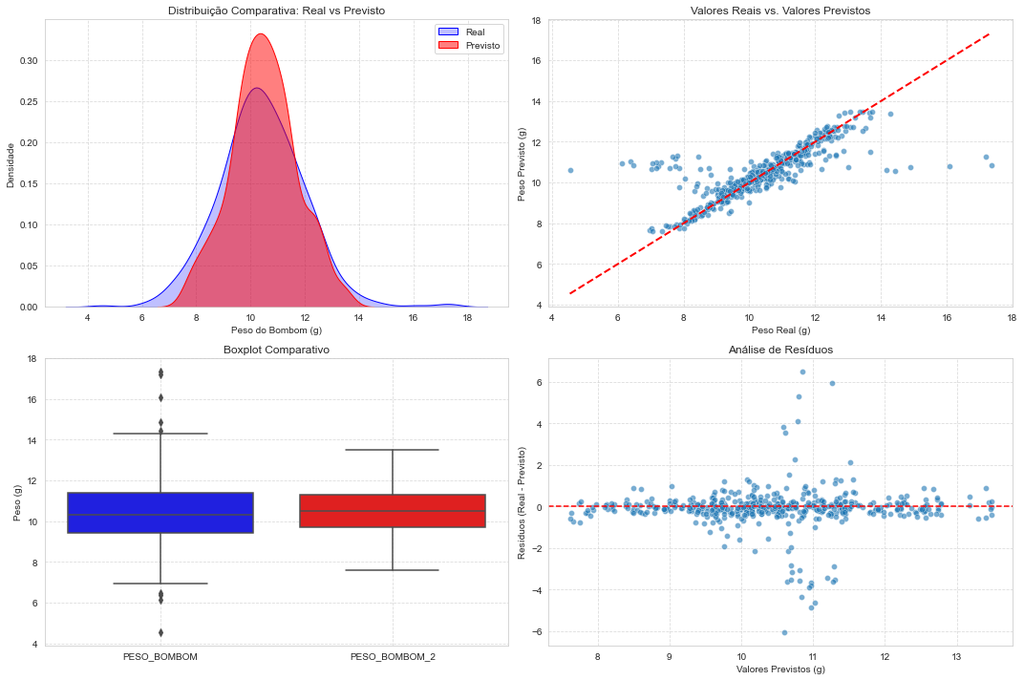

```
Comparativo por Categoria VAR_2:

Valores Reais:
```

| VAR_2 | count | mean | std | min | 25% | 50% | 75% | max |
| --- | --- | --- | --- | --- | --- | --- | --- | --- |
| A | 158.0 | 11.659115 | 0.981347 | 9.031698 | 10.947130 | 11.709176 | 12.360977 | 14.292523 |
| B | 165.0 | 9.595768 | 1.153189 | 6.963430 | 8.746576 | 9.501539 | 10.630583 | 12.256938 |
| C | 177.0 | 10.011633 | 1.651963 | 4.543124 | 9.351677 | 9.994334 | 10.510154 | 17.362728 |

```
Valores Previstos:
```

| VAR_2 | count | mean | std | min | 25% | 50% | 75% | max |
| --- | --- | --- | --- | --- | --- | --- | --- | --- |
| A | 158.0 | 11.678515 | 0.868664 | 9.847866 | 11.114589 | 11.542406 | 12.301528 | 13.484768 |
| B | 165.0 | 9.577026 | 1.072452 | 7.612905 | 8.742477 | 9.458546 | 10.490879 | 11.581740 |
| C | 177.0 | 10.255110 | 0.526924 | 9.263239 | 9.764437 | 10.170445 | 10.671311 | 11.330907 |

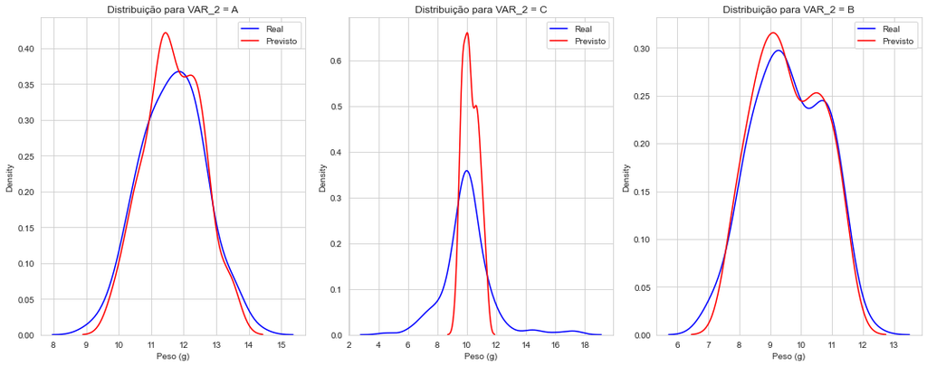

```
Tabela Comparativa Detalhada:
```

|  | QTD_CHOC | VAR_1 | PESO_BOMBOM | PESO_BOMBOM_2 |
| --- | --- | --- | --- | --- |
| count | 500.000000 | 500.000000 | 500.000000 | 500.000000 |
| mean | 291.264600 | 2.098180 | 10.395002 | 10.481138 |
| std | 45.182499 | 0.711166 | 1.572233 | 1.206531 |
| min | 112.910000 | 0.050000 | 4.543124 | 7.612905 |
| 25% | 259.267500 | 1.630000 | 9.425819 | 9.715184 |
| 50% | 295.450000 | 2.300000 | 10.334273 | 10.489768 |
| 75% | 325.137500 | 2.672500 | 11.379932 | 11.277584 |
| max | 436.070000 | 2.980000 | 17.362728 | 13.484768 |

```python
# Previsões no df de produção
df['INTERACTION'] = df['QTD_CHOC'] * df['VAR_1']
df['PESO_BOMBOM_2'] = best_model.predict(df[['QTD_CHOC', 'VAR_1', 'VAR_2', 'INTERACTION']])

mse = mean_squared_error(df['PESO_BOMBOM'], df['PESO_BOMBOM_2'])
r2 = r2_score(df['PESO_BOMBOM'], df['PESO_BOMBOM_2'])

print(f"\nMétricas de Desempenho no Conjunto Completo:")
print(f"MSE: {mse:.4f}")
print(f"R²: {r2:.4f}")


plt.figure(figsize=(15, 10))
# Gráfico 1: Distribuição comparativa
plt.subplot(2, 2, 1)
sns.kdeplot(df['PESO_BOMBOM'], label='Real', color='blue', fill=True)
sns.kdeplot(df['PESO_BOMBOM_2'], label='Previsto', color='red', fill=True, alpha=0.5)
plt.title('Distribuição Comparativa: Real vs Previsto')
plt.xlabel('Peso do Bombom (g)')
plt.ylabel('Densidade')
plt.legend()
plt.grid(True, linestyle='--', alpha=0.7)

# Gráfico 2: Dispersão Real vs Previsto
plt.subplot(2, 2, 2)
sns.scatterplot(x='PESO_BOMBOM', y='PESO_BOMBOM_2', data=df, alpha=0.6)
plt.plot([df['PESO_BOMBOM'].min(), df['PESO_BOMBOM'].max()],
         [df['PESO_BOMBOM'].min(), df['PESO_BOMBOM'].max()],
         '--', color='red', linewidth=2)
plt.title('Valores Reais vs. Valores Previstos')
plt.xlabel('Peso Real (g)')
plt.ylabel('Peso Previsto (g)')
plt.grid(True, linestyle='--', alpha=0.7)

# Gráfico 3: Boxplot comparativo
plt.subplot(2, 2, 3)
sns.boxplot(data=df[['PESO_BOMBOM', 'PESO_BOMBOM_2']], palette=['blue', 'red'])
plt.title('Boxplot Comparativo')
plt.ylabel('Peso (g)')
plt.grid(True, linestyle='--', alpha=0.7)

# Gráfico 4: Resíduos
plt.subplot(2, 2, 4)
residuos = df['PESO_BOMBOM'] - df['PESO_BOMBOM_2']
sns.scatterplot(x=df['PESO_BOMBOM_2'], y=residuos, alpha=0.6)
plt.axhline(y=0, color='red', linestyle='--')
plt.title('Análise de Resíduos')
plt.xlabel('Valores Previstos (g)')
plt.ylabel('Resíduos (Real - Previsto)')
plt.grid(True, linestyle='--', alpha=0.7)

plt.tight_layout()
plt.show()

# 4. Análise por Categoria VAR_2
if 'VAR_2' in df.columns:
    print("\nComparativo por Categoria VAR_2:")

    # Estatísticas descritivas
    stats_real = df.groupby('VAR_2')['PESO_BOMBOM'].describe()
    stats_pred = df.groupby('VAR_2')['PESO_BOMBOM_2'].describe()

    print("\nValores Reais:")
    display(stats_real)

    print("\nValores Previstos:")
    display(stats_pred)

    # Visualização por categoria
    plt.figure(figsize=(15, 6))

    for i, var in enumerate(df['VAR_2'].unique(), 1):
        plt.subplot(1, len(df['VAR_2'].unique()), i)
        subset = df[df['VAR_2'] == var]
        sns.kdeplot(subset['PESO_BOMBOM'], label='Real', color='blue')
        sns.kdeplot(subset['PESO_BOMBOM_2'], label='Previsto', color='red')
        plt.title(f'Distribuição para VAR_2 = {var}')
        plt.xlabel('Peso (g)')
        plt.legend()

    plt.tight_layout()
    plt.show()

# 5. Comparação detalhada
print("\nTabela Comparativa Detalhada:")
comparison_table = df[['QTD_CHOC', 'VAR_1', 'VAR_2', 'PESO_BOMBOM', 'PESO_BOMBOM_2']].copy()
display(comparison_table.describe())

# Opcional: Salvar resultados em CSV
comparison_table.to_csv("C:/Users/pcdan/Downloads/case_IBM/comparacao_pesos_reais_vs_previstos.csv", sep=';', index=False)
```

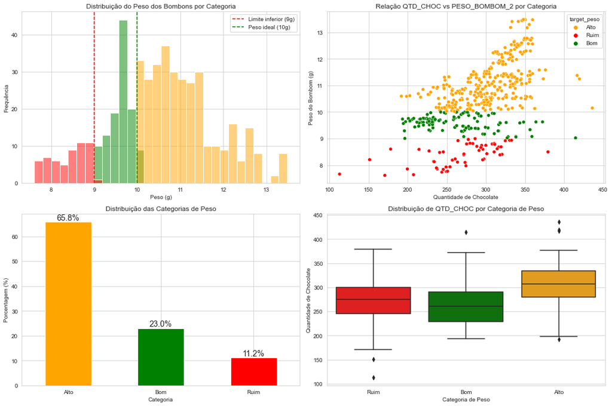

```python
# Classificação do peso
df['target_peso'] = np.where(df['PESO_BOMBOM_2'] > 10.0, "Alto",
                    np.where((df['PESO_BOMBOM_2'] >= 9.0) & (df['PESO_BOMBOM_2'] <= 10.0), "Bom",
                             "Ruim"))

# Categorias de conformidade
conforme = df[(df['PESO_BOMBOM_2'] >= 9.0) & (df['PESO_BOMBOM_2'] <= 10.0)]
conforme_custo_alto = df[(df['PESO_BOMBOM_2'] > 10.0)]
nao_conforme = df[(df['PESO_BOMBOM_2'] < 9.0)]

plt.figure(figsize=(15, 10))

# Relação Target_Peso vs PESO_BOMBOM_2 com categorias
plt.subplot(2, 2, 1)
sns.histplot(data=df, x='PESO_BOMBOM_2', hue='target_peso', bins=30, palette={'Ruim': 'red', 'Bom': 'green', 'Alto': 'orange'})
plt.axvline(x=9.0, color='r', linestyle='--', label='Limite inferior (9g)')
plt.axvline(x=10.0, color='g', linestyle='--', label='Peso ideal (10g)')
plt.title('Distribuição do Peso dos Bombons por Categoria')
plt.xlabel('Peso (g)')
plt.ylabel('Frequência')
plt.legend()

# Relação QTD_CHOC vs PESO_BOMBOM_2 com categorias
plt.subplot(2, 2, 2)
sns.scatterplot(x='QTD_CHOC', y='PESO_BOMBOM_2', hue='target_peso', data=df, palette={'Ruim': 'red', 'Bom': 'green', 'Alto': 'orange'})
plt.title('Relação QTD_CHOC vs PESO_BOMBOM_2 por Categoria')
plt.xlabel('Quantidade de Chocolate')
plt.ylabel('Peso do Bombom (g)')

# Proporção de cada categoria
plt.subplot(2, 2, 3)
categorias = df['target_peso'].value_counts(normalize=True) * 100
categorias.plot(kind='bar', color=['orange', 'green', 'red'])
plt.title('Distribuição das Categorias de Peso')
plt.xlabel('Categoria')
plt.ylabel('Porcentagem (%)')
plt.bar_label(plt.gca().containers[0], fmt='%.1f%%', fontsize=14)
plt.xticks(rotation=0)

# Boxplot de QTD_CHOC por categoria
plt.subplot(2, 2, 4)
sns.boxplot(x='target_peso', y='QTD_CHOC', data=df, order=['Ruim', 'Bom', 'Alto'], palette={'Ruim': 'red', 'Bom': 'green', 'Alto': 'orange'})
plt.title('Distribuição de QTD_CHOC por Categoria de Peso')
plt.xlabel('Categoria de Peso')
plt.ylabel('Quantidade de Chocolate')

plt.tight_layout()
plt.show()
```

```python
df.groupby('target_peso').size().reset_index(name='counts')
```

|  | target_peso | counts |
| --- | --- | --- |
| 0 | Alto | 329 |
| 1 | Bom | 115 |
| 2 | Ruim | 56 |

```python
# Definir a função de custo
def calcular_custo(p):
    """
    Calcula o custo C(p) baseado no peso p do bombom.

    Parâmetros:
    p -- peso do bombom (float)

    Retorna:
    Valor do custo calculado
    """
    termo1 = 200 / (1 + np.exp(10 * (p - 9.5)))
    termo2 = 200 / (1 + np.exp(-0.8 * (p - 12)))
    return termo1 + termo2

df['custo'] = calcular_custo(df['PESO_BOMBOM_2'])

print("\nEstatísticas descritivas do custo:")
df_custo = df['custo'].describe().to_frame(name='custo')
df_custo
```

```
Estatísticas descritivas do custo:
```

|  | custo |
| --- | --- |
| count | 500.000000 |
| mean | 91.541976 |
| std | 59.231356 |
| min | 34.690405 |
| 25% | 46.605482 |
| 50% | 69.119627 |
| 75% | 120.490050 |
| max | 215.299553 |

```python
# Cálculo da distribuição percentual do custo- Por Classe
agg_class = (
    df[['target_peso', 'VAR_2','custo']].groupby(['target_peso', 'VAR_2'])
    .sum('custo')
    .unstack(fill_value=0)
    .round(0)
)

agg_percent = agg_class.div(agg_class.sum(axis=0))*100
agg_percent_tl = pd.concat([
    agg_class.add_suffix('_n'),
    agg_percent.round(1).add_suffix('_%')
], axis=1)

agg_percent_tl.loc['Total'] = agg_percent_tl.sum(axis=0)

agg_percent_tl
```

| VAR_2 target_peso | custo_n A_n | custo_n B_n | custo_n C_n | custo_% A_% | custo_% B_% | custo_% C_% |
| --- | --- | --- | --- | --- | --- | --- |
| Alto | 13827.0 | 3439.0 | 5561.0 | 98.7 | 15.7 | 56.1 |
| Bom | 179.0 | 6608.0 | 4345.0 | 1.3 | 30.2 | 43.9 |
| Ruim | 0.0 | 11811.0 | 0.0 | 0.0 | 54.0 | 0.0 |
| Total | 14006.0 | 21858.0 | 9906.0 | 100.0 | 99.9 | 100.0 |

```python
# Cálculo da distribuição percentual - Por Target Peso
agg_target_percentil = (
    df[['target_peso', 'VAR_2','custo']].groupby(['target_peso', 'VAR_2'])
    .sum('custo')
    .unstack(fill_value=0)
    .apply(lambda x: x/x.sum()*100, axis=1)
    .round(0)
)
agg_target_percentil['Total'] = agg_target_percentil.sum(axis=1)
agg_target_percentil
```

| VAR_2 target_peso | custo A | custo B | custo C | Total |
| --- | --- | --- | --- | --- |
| Alto | 61.0 | 15.0 | 24.0 | 100.0 |
| Bom | 2.0 | 59.0 | 39.0 | 100.0 |
| Ruim | 0.0 | 100.0 | 0.0 | 100.0 |

### 3.7. Perspectivas da Análise Preditiva:

#### Pipeline

A pipeline de treino foi desenvolvida seguindo as etapas abaixo:

1. **Pré-processamento**:
   - Conversão da variável categórica `VAR_2` usando `OneHotEncoder`.
   - Criação de uma feature de interação (`INTERACTION`) entre `QTD_CHOC` e `VAR_1` para capturar relações não lineares.
   - Remoção de outliers da classe `C` da variável `PESO_BOMBOM` para melhorar a qualidade dos dados.
2. **Divisão dos Dados**:
   - Os dados foram divididos em conjuntos de treino (80%) e teste (20%) para avaliação justa dos modelos.
3. **Modelos Baseline**:
   - Foram testados três algoritmos: `Random Forest`, `Gradient Boosting` e `Regressão Linear`.
   - O `Random Forest` se destacou com o menor MSE (0.2281) e o maior R² (0.8710) na fase de otimização.
4. **Otimização de Hiperparâmetros**:
   - Utilizou-se `GridSearchCV` para ajustar os hiperparâmetros de cada modelo, como número de árvores, profundidade máxima e taxa de aprendizado.
   - O `Random Forest` otimizado apresentou os melhores resultados, com parâmetros como `max_depth=10` e `n_estimators=300`.
5. **Feature Importance**:
   - A variável `VAR_2_A` foi a mais relevante (42%), seguida pela interação `INTERACTION` (34%), indicando que a categoria e a combinação de features têm grande influência no peso do bombom.

#### Oportunidades de Melhoria

- Explorar outras interações ou transformações (como logarítmicas) para capturar melhor relações não lineares.
- Incluir variáveis externas ou temporais, se disponíveis, para enriquecer o contexto.
- Investigar a distribuição das classes em `VAR_2` e aplicar técnicas como oversampling/undersampling se houver desequilíbrio.
- Testar algoritmos como `XGBoost` ou `SVR`, que podem lidar melhor com padrões complexos.
- Implementar `cross-validation` estratificada para garantir robustez em todas as categorias.
- Utilizar técnicas como **SHAP** para explicar as previsões do modelo, especialmente em casos extremos.

## **4. Análise Prescritiva**

Analises não finalizadas

## **Recomendações Finais**

1. Implementar monitoramento contínuo da performance do modelo
2. Re-treinar o modelo periodicamente com novos dados:
   - input de novas features como caracteristicas de máquinas, temperatura, etc;
   - temperatura do chocolate "cobertura", com base no tempo de aplicação. Precisão de aplicação, e secagem.
3. Considerar a implementação de um sistema de alerta para predições fora do esperado
4. Documentar todas as decisões de modelagem para rastreabilidade
5. **Sistema com analise computacional para classificar**: Criação de um modelo de Deep Learning com CNN (rede convulucionais de imagem) - para avaliação do diametro do bombom, e estimativa de aplicação da massa no produto, o que pode minimizar a função de custo do processo, e equilibrar o peso. Isso maximizado com o modelo de regressão que estima a quantidade ideal;